# Vectores 2D

*Universidad Autonoma del Estado de Mexico*

*Centro Universitario Zumpango*

*Profesora: Hazem Alvarez*

*Alumno: Luis Angel Garcia Montiel*

*Graficacion Computacional*

*Ingenieria en computacion*

```python
import numpy as np # soporte para vectores
import matplotlib.pyplot as plt # graficador
```

numpy: Es una biblioteca que permite trabajar con arreglos y realizar operaciones matemáticas eficientes.

matplotlib.pyplot: Este módulo nos permite crear gráficos visuales.

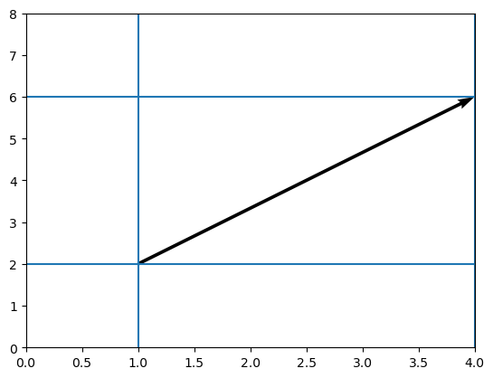

```python
plt.quiver(1,2, 3,4, scale_units='xy', angles='xy', scale=1)
plt.xlim(0,4)
plt.ylim(0,8)

# guias
plt.axvline(x=1)
plt.axhline(y=2)

plt.axvline(x=1+3)
plt.axhline(y=2+4)
```

plt.quiver: Dibuja un vector en un gráfico. Los parámetros incluyen la posición inicial del vector y su dirección.

plt.xlim y plt.ylim: Configuran los límites de los ejes x e y.

plt.axvline y plt.axhline: Añaden líneas verticales y horizontales en las posiciones especificadas para guiar la visualización.

```
(0.0, 4.0)
```

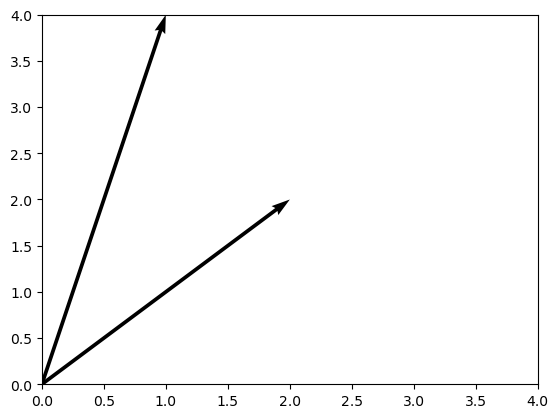

```python
plt.quiver([0,0],[0,0],[1,2],[4,2], scale_units='xy', angles='xy', scale=1)
plt.xlim(0,4)
plt.ylim(0,4)
```

plt.quiver: Dibuja múltiples vectores en el gráfico con direcciones y posiciones especificadas.

plt.xlim y plt.ylim: Configuran los límites de los ejes x e y.

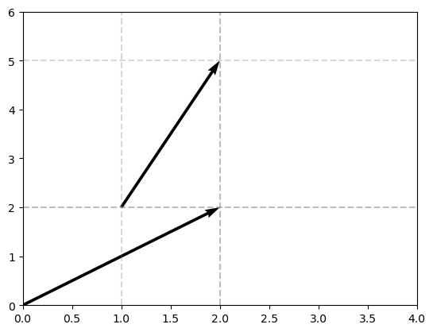

```python
plt.quiver([1,0],[2,0],[1,2],[3,2], scale_units='xy', angles='xy', scale=1)
plt.xlim(0,4)
plt.ylim(0,6)

plt.axvline(x=1, color='gray', linestyle='--', alpha=0.3)
plt.axhline(y=2, color='gray', linestyle='--', alpha=0.3)

plt.axvline(x=2, color='gray', linestyle='--', alpha=0.3)
plt.axhline(y=2, color='gray', linestyle='--', alpha=0.3)

plt.axvline(x=2, color='gray', linestyle='--', alpha=0.3)
plt.axhline(y=5, color='gray', linestyle='--', alpha=0.3)
```

plt.xlim y plt.ylim: Ajustan los límites de los ejes x e y.

plt.axvline y plt.axhline: Añaden líneas verticales y horizontales con estilo y opacidad especificados para guiar la visualización.

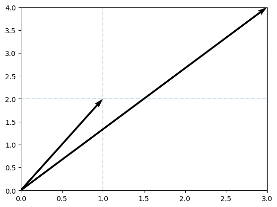

```python
v1 = np.array([1,2])
v2 = np.array([3,4])

plt.quiver([0,0],[0,0],[v1[0],v2[0]],[v1[1],v2[1]],angles='xy', scale_units='xy', scale=1)
plt.xlim(0, max(v1[0], v2[0]))
plt.ylim(0, max(v1[1], v2[1]))

plt.axvline(x=1, alpha=0.2, linestyle='--')
plt.axhline(y=2, alpha=0.2, linestyle='--')
plt.axvline(x=3, alpha=0.2, linestyle='--')
plt.axhline(y=4, alpha=0.2, linestyle='--')
```

La función grafvecs se define para aceptar dos argumentos:

vecs: Una lista de vectores que se desean graficar.

cols: Una lista de colores, donde cada color corresponde a uno de los vectores en la lista vecs.

Se crea una nueva figura para el gráfico con un tamaño específico de 5x5 pulgadas. Esto proporciona un área donde los vectores serán visualizados.

La función itera sobre la lista de vectores vecs utilizando un bucle

Para cada índice en la lista de vectores, se obtiene el vector correspondiente.

Se dibuja un vector en el gráfico comenzando desde el origen (0,0) y extendiéndose hasta el punto definido por el vector actual.

El color del vector se asigna según la lista cols, de modo que cada vector tiene el color correspondiente de la lista.

```python
def grafvecs(vecs, cols):
    plt.figure(figsize=(5,5))
    # vecs: lista de vectores
    for i in range(len(vecs)):
        vec = vecs[i]
        plt.quiver(0,0, vec[0], vec[1], color = cols[i],
                   angles='xy', scale_units='xy', scale=1)
```

grafvecs: Define una función para graficar múltiples vectores con colores específicos.

plt.figure: Crea una nueva figura de gráfico con tamaño específico.

Bucle for: Itera sobre los vectores y los grafica con los colores especificados.

```
(0.0, 4.0)
```

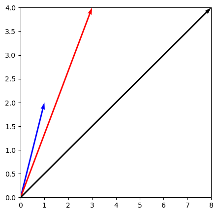

```python
v1 = np.array([1,2])
v2 = np.array([3,4])
v3 = np.array([8,4])

grafvecs([v1, v2, v3], ['blue', 'red', 'black'])
plt.xlim(0, max(v1[0], v2[0], v3[0]))
plt.ylim(0, max(v1[1], v2[1], v3[1]))
```

Crea tres vectores utilizando numpy.

grafvecs para graficar los vectores v1, v2 y v3.

Asigna los colores 'blue', 'red' y 'black' a v1, v2 y v3, respectivamente.

Establece el límite del eje x desde 0 hasta el valor máximo de las componentes x de los vectores.

Establece el límite del eje y desde 0 hasta el valor máximo de las componentes y de los vectores.